# The Elo method in chess

## Data

We use the `data.csv`: games between pairs of players, with columns `White`, `Black` and `Score` (1 = White win, 0.5 = draw, 0 = Black win).

```r
games <- read.csv("data.csv")
str(games)
```

```
## 'data.frame':    65053 obs. of  3 variables:
##  $ White: int  73 73 73 73 73 88 88 88 154 158 ...
##  $ Black: int  1246 5097 5104 7321 7375 1033 1860 4858 3377 8059 ...
##  $ Score: num  0.5 0.5 0.5 1 0.5 0.5 1 1 0 1 ...
```

```r
players   <- sort(unique(c(games$White, games$Black)))
n_players <- length(players)
idx       <- setNames(seq_along(players), players)

cat("Number of games  :", nrow(games), "\n")
```

```
## Number of games  : 65053
```

```r
cat("Number of players:", n_players, "\n")
```

```
## Number of players: 7301
```

## Challenge 1 — Does White have a first-mover advantage?

If there were no advantage to moving first, White’s score in any game would average 0.5 (a win counts 1, a draw 0.5, a loss 0). We test `H0: E[Score] = 0.5` against the two-sided alternative `H1` using the large-sample normal approximation (n is large enough that the CLT (Central Limit Theorem) applies comfortably).

```r
white_mean <- mean(games$Score)
n          <- nrow(games)
se         <- sd(games$Score) / sqrt(n)
z_stat     <- (white_mean - 0.5) / se
p_value    <- 2 * (1 - pnorm(abs(z_stat)))

rates <- c(
  "White win" = mean(games$Score == 1),
  "Draw"      = mean(games$Score == 0.5),
  "Black win" = mean(games$Score == 0)
)

cat(sprintf("Mean White score     : %.4f  (0.5 = no advantage)\n", white_mean))
```

```
## Mean White score     : 0.5456  (0.5 = no advantage)
```

```r
cat(sprintf("z = %.2f,  p-value = %.3g\n", z_stat, p_value))
```

```
## z = 31.37,  p-value = 0
```

**Conclusion.** White’s average score (0.5456) is significantly above 0.5 (z = 31.4, p < 0.001). The effect is small in absolute size but, with 65,053 games behind it, is extremely unlikely to be chance. **White does have a first-mover advantage.**

## Challenge 2 — Point rating

A player’s *point rating* is simply the total number of points earned: 1 per win, 0.5 per draw, 0 per loss, added up over every game the player took part in (regardless of colour).

```r
point_rating <- function(games) {
  players <- sort(unique(c(games$White, games$Black)))
  idx     <- setNames(seq_along(players), players)
  pts     <- numeric(length(players))
  gp      <- numeric(length(players))

  wi <- idx[as.character(games$White)]
  bi <- idx[as.character(games$Black)]
  sc <- games$Score

  # vectorized accumulation (fast; no explicit per-row R loop)
  pts <- as.numeric(tapply(c(sc, 1 - sc), c(wi, bi), sum, default = 0))
  gp  <- as.numeric(table(factor(c(wi, bi), levels = seq_along(players))))

  data.frame(player = players, points = pts, games = gp)
}

pr <- point_rating(games)
summary(pr$points)
```

```
##    Min. 1st Qu.  Median    Mean 3rd Qu.    Max.
##    0.00    1.00    3.00    8.91    9.00  167.50
```

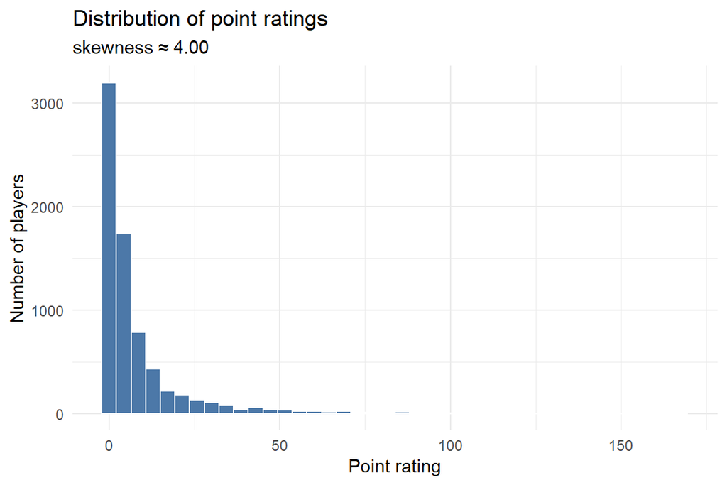

```r
skewness <- function(x) mean((x - mean(x))^3) / sd(x)^3

ggplot(pr, aes(points)) +
  geom_histogram(bins = 40, fill = "#4C78A8", color = "white") +
  labs(title = "Distribution of point ratings",
       subtitle = sprintf("skewness ≈ %.2f", skewness(pr$points)),
       x = "Point rating", y = "Number of players") +
  theme_minimal()
```

**Discussion.** The distribution is strongly **right-skewed**: most players have only a handful of points, while a long tail of very active players has accumulated far more. This is mechanical, not a sign of exceptional skill — a player who plays many games will out-score a much stronger player who has only played a few, simply by volume. Point rating conflates *activity* with *ability*, which motivates a rating system that measures relative skill instead (Challenge 4).

## Challenge 3 — Proof that $\sum_i r_i = 0$ always

We are given, for every pair of players $(i,j)$ who face each other:

$$s_{i,j} + s_{j,i} = 1 \qquad
\text{(actual scores of the two sides in one game sum to 1)}$$
$$\mu_{i,j} + \mu_{j,i} = 1 \qquad
\text{(expected scores sum to 1, by construction of the logistic }
\mu)$$

The Elo update after a single game between $i$ (as one side) and $j$ (as the other) is

$$r_i \leftarrow r_i + \kappa\,(s_{i,j} -
\mu_{i,j}), \qquad r_j \leftarrow r_j + \kappa\,(s_{j,i} -
\mu_{j,i}).$$

**Claim.** $\sum_k r_k$ is invariant (always equal to its initial value, which is 0 since every rating starts at 0).

**Proof.** Every update touches only the two ratings $r_i, r_j$ involved in that game; every other player’s rating is unchanged, so the only thing that can move the total $\sum_k r_k$ is the sum of the two deltas applied in that game:

$$\Delta\!\left(\sum_k r_k\right) =
\kappa(s_{i,j}-\mu_{i,j}) + \kappa(s_{j,i}-\mu_{j,i})
= \kappa\Big[(s_{i,j}+s_{j,i}) - (\mu_{i,j}+\mu_{j,i})\Big] =
\kappa\,[\,1 - 1\,] = 0.$$

So a single game update leaves $\sum_k r_k$ exactly unchanged — the rating points transferred to $i$ are precisely the rating points removed from $j$ (or vice versa): Elo is a **closed, zero-sum** accounting system. Since $\sum_k r_k = 0$ at initialization and every subsequent update (over every game, every epoch, in any order) preserves the sum, by induction $\sum_k r_k = 0$ **at all times**. $\blacksquare$

## Challenge 4 — Elo rating

The proof above is exactly what lets the implementation be *optimized*: because $\mu_{j,i}$ is always $1-\mu_{i,j}$ and the two deltas are always equal and opposite, we only need to compute **one** expected score per game and apply it with a $\pm$ sign — there is never a need for a separate renormalization step to keep the ratings zero-sum, because the update mechanics guarantee it automatically.

```r
elo_rating <- function(games, zeta = 400, kappa = 25, n_epochs = 10, seed = 1) {
  players <- sort(unique(c(games$White, games$Black)))
  idx     <- setNames(seq_along(players), players)
  wi <- idx[as.character(games$White)]
  bi <- idx[as.character(games$Black)]
  sc <- games$Score
  n_games <- length(sc)

  r <- numeric(length(players))   # all ratings start at 0 -> sum already 0
  set.seed(seed)

  for (epoch in seq_len(n_epochs)) {
    ord <- sample.int(n_games)          # re-shuffle game order each epoch
    for (g in ord) {
      i <- wi[g]; j <- bi[g]; s <- sc[g]
      mu    <- 1 / (1 + 10^(-(r[i] - r[j]) / zeta))  # only ONE expected score needed
      delta <- kappa * (s - mu)
      r[i]  <- r[i] + delta    # zero-sum: no separate mu_ji, no renormalization
      r[j]  <- r[j] - delta    #           ever needed -- see Challenge 3 proof
    }
  }
  data.frame(player = players, elo = r)
}

er <- elo_rating(games, n_epochs = 10)
summary(er$elo)
```

```
##     Min.  1st Qu.   Median     Mean  3rd Qu.     Max.
## -450.651  -87.842   -3.879    0.000   80.248  422.095
```

```r
cat(sprintf("Sum of all Elo ratings (should be ~0): %.6g\n", sum(er$elo)))
```

```
## Sum of all Elo ratings (should be ~0): -2.05586e-12
```

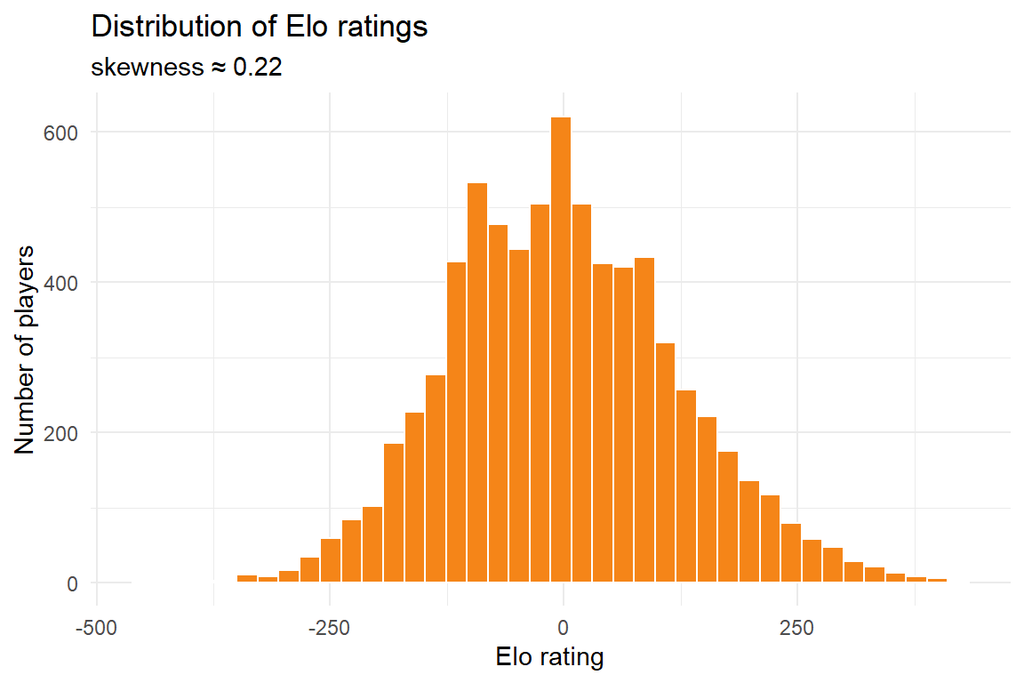

```r
ggplot(er, aes(elo)) +
  geom_histogram(bins = 40, fill = "#F58518", color = "white") +
  labs(title = "Distribution of Elo ratings",
       subtitle = sprintf("skewness ≈ %.2f", skewness(er$elo)),
       x = "Elo rating", y = "Number of players") +
  theme_minimal()
```

## Challenge 5 — Are point rating and Elo rating correlated? Do the same players top both lists?

```r
comb <- merge(pr, er, by = "player")

pearson_r  <- cor(comb$points, comb$elo, method = "pearson")
spearman_r <- cor(comb$points, comb$elo, method = "spearman")

cat(sprintf("Pearson correlation (points, elo)  = %.3f\n", pearson_r))
```

```
## Pearson correlation (points, elo)  = 0.590
```

```r
cat(sprintf("Spearman correlation (points, elo) = %.3f\n", spearman_r))
```

```
## Spearman correlation (points, elo) = 0.630
```

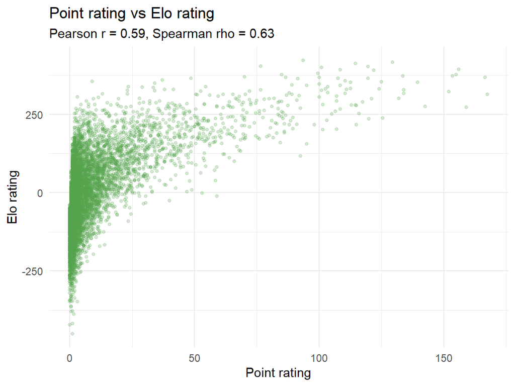

```r
ggplot(comb, aes(points, elo)) +
  geom_point(alpha = 0.25, color = "#54A24B", size = 1) +
  labs(title = "Point rating vs Elo rating",
       subtitle = sprintf("Pearson r = %.2f, Spearman rho = %.2f", pearson_r, spearman_r),
       x = "Point rating", y = "Elo rating") +
  theme_minimal()
```

```r
K <- 20
top_points <- comb$player[order(-comb$points)][1:K]
top_elo    <- comb$player[order(-comb$elo)][1:K]
overlap    <- intersect(top_points, top_elo)

knitr::kable(
  data.frame(
    Rank             = 1:K,
    `Top by points`  = top_points,
    `Top by Elo`     = top_elo,
    check.names = FALSE
  ),
  align = "rrr",
  caption = sprintf("Top-%d players by each rating (overlap: %d of %d players appear on both lists)",
                     K, length(overlap), K)
)
```

Top-20 players by each rating (overlap: 7 of 20 players appear on both lists)

| Rank | Top by points | Top by Elo |
| --- | --- | --- |
| 1 | 4037 | 158 |
| 2 | 1286 | 3344 |
| 3 | 4850 | 7848 |
| 4 | 1594 | 7715 |
| 5 | 64 | 7953 |
| 6 | 1098 | 8121 |
| 7 | 391 | 1594 |
| 8 | 1512 | 4194 |
| 9 | 5050 | 8287 |
| 10 | 2283 | 2295 |
| 11 | 2599 | 64 |
| 12 | 1397 | 7593 |
| 13 | 4171 | 1098 |
| 14 | 3344 | 1397 |
| 15 | 6586 | 1746 |
| 16 | 5942 | 2997 |
| 17 | 7638 | 1286 |
| 18 | 8287 | 8190 |
| 19 | 6691 | 5531 |
| 20 | 6270 | 4082 |

**Conclusion.** The two ratings are positively but only moderately correlated (Pearson r ≈ 0.59, Spearman rho ≈ 0.63): players who do well tend to score well under both systems, but the relationship is far from 1-to-1, and the overlap between the two top-20 lists is partial, not complete. This is consistent with Challenge 2’s finding that point rating is substantially inflated by games played: a very active, moderately-good player can out-score (in points) a less active but genuinely stronger player, while Elo ranks the latter higher.

## Challenge 6 — Does the number of games played affect rating?

```r
pearson_gp <- cor(comb$games, comb$points, method = "pearson")
pearson_ge <- cor(comb$games, comb$elo,    method = "pearson")
spear_gp   <- cor(comb$games, comb$points, method = "spearman")
spear_ge   <- cor(comb$games, comb$elo,    method = "spearman")

cat(sprintf("games vs points : Pearson r = %.3f, Spearman rho = %.3f\n", pearson_gp, spear_gp))
```

```
## games vs points : Pearson r = 0.990, Spearman rho = 0.947
```

```r
cat(sprintf("games vs elo    : Pearson r = %.3f, Spearman rho = %.3f\n", pearson_ge, spear_ge))
```

```
## games vs elo    : Pearson r = 0.538, Spearman rho = 0.409
```

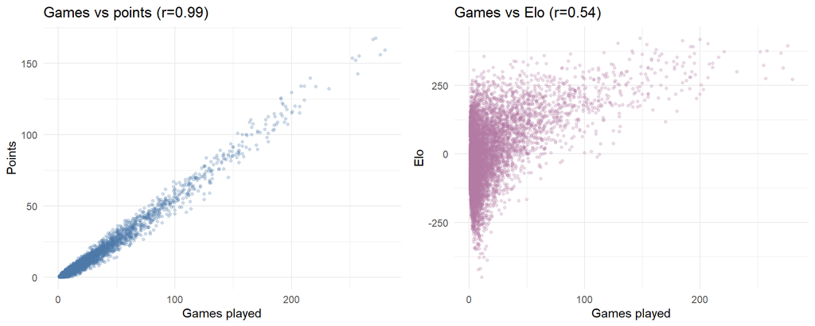

```r
p1 <- ggplot(comb, aes(games, points)) +
  geom_point(alpha = 0.25, color = "#4C78A8", size = 1) +
  labs(title = sprintf("Games vs points (r=%.2f)", pearson_gp), x = "Games played", y = "Points") +
  theme_minimal()

p2 <- ggplot(comb, aes(games, elo)) +
  geom_point(alpha = 0.25, color = "#B279A2", size = 1) +
  labs(title = sprintf("Games vs Elo (r=%.2f)", pearson_ge), x = "Games played", y = "Elo") +
  theme_minimal()

gridExtra_available <- requireNamespace("gridExtra", quietly = TRUE)
if (gridExtra_available) {
  gridExtra::grid.arrange(p1, p2, ncol = 2)
} else {
  print(p1); print(p2)
}
```

```r
comb$games_bucket <- cut(comb$games, breaks = quantile(comb$games, probs = seq(0, 1, 0.2)),
                          include.lowest = TRUE)

agg <- comb %>%
  group_by(games_bucket) %>%
  summarise(n = n(),
            mean_points = mean(points), sd_points = sd(points),
            mean_elo = mean(elo),       sd_elo = sd(elo))

knitr::kable(
  agg, digits = 2,
  col.names = c("Games played (range)", "Players (n)",
                "Avg. point rating", "Point rating SD",
                "Avg. Elo rating", "Elo rating SD"),
  align = "lrrrrr",
  caption = "Rating summary by games-played quintile"
)
```

Rating summary by games-played quintile

| Games played (range) | Players (n) | Avg. point rating | Point rating SD | Avg. Elo rating | Elo rating SD |
| --- | --- | --- | --- | --- | --- |
| [1,2] | 1595 | 0.54 | 0.51 | -32.25 | 84.78 |
| (2,5] | 1527 | 1.49 | 0.83 | -46.13 | 106.30 |
| (5,10] | 1291 | 3.13 | 1.33 | -40.94 | 117.23 |
| (10,24] | 1432 | 7.29 | 2.73 | 1.56 | 108.95 |
| (24,280] | 1456 | 32.57 | 25.48 | 118.48 | 110.09 |

## Summary

[output not shown]